# WR analysis of RoH and Froh

Fátima S. Barreiro

April 21, 2020

Load required libraries

```r
library(ggplot2)
library(cowplot)
library(ggrepel)
library(reshape2)
library(dplyr)
library(tidyverse)
library(data.table)
require(scales)
library(ggpubr)
library(tidyr)
library(PairedData)
library(gridExtra)
```

Reading in file containing metadata

```r
data = read.csv("WR_v3_TableS1_v1.csv", h=T, fill=T, stringsAsFactors=T, fileEncoding="latin1")
```

## Local heterozygosity distribution across windows (1Mbp, 0.5 Mbp slide)

Visualize distribution of heterozygosity values per sample

```r
# read het data across 52 inds
hets = read.table("WR_hetwindows_info.hets", header=T)

## change headers in order to use new IDs instead of the old ones
# get only columns corresponding to sample values
hets_noinfo = hets[,4:55]
# get new id labels from metadata
metadata <-read.csv("/home/fatima/Documents/PhD/COMPUTATIONAL/metadata/WR_PaleomixStats_metadata_final.csv", h=T, fill=T, stringsAsFactors=T, fileEncoding="latin1")
new_ID = metadata$new_ID
# change column names on data
colnames(hets_noinfo) = new_ID
hets_newID = cbind(hets[,1:3], hets_noinfo)

## reshape dataframes with old ID and new ID to then get the names of the old IDs as an extra column
df_oldID = reshape2::melt(hets, id.vars=c("scaffold", "midpoint", "window"))
setnames(df_oldID, "variable", "oldID")

df_newID = reshape2::melt(hets_newID, id.vars=c("scaffold", "midpoint", "window"))

# rename the extra old ID column as oldID only
df = cbind(df_newID, df_oldID$oldID)
setnames(df, "df_oldID$oldID", "oldID")
```

Make subsets of the data per group

```r
## subset data to avoid collapsing R due to huge data frame
NWR1_names = c("mwr_TG0450", "mwr_TG0451", "mwr_TG0452", "mwr_TG0453", "mwr_TG0454", "mwr_TG0455", "mwr_TG0456", "mwr_TG0458", "mwr_TG0460", "mwr_TG0461", "mwr_TG0462", "mwr_TG0463", "mwr_TG0465", "mwr_TGF14", "mwr_TGF15", "mwr_TGF16")
NWR1 = df[df$oldID %in% NWR1_names,]

NWR2_names = c("wr_SRR5852741", "wr_SRR5852742", "wr_SRR5852743", "wr_SRR5852744", "wr_SRR5852745", "wr_SRR5852746", "wr_SRR5852747", "wr_SRR5852748", "wr_SRR5852749")
NWR2 = df[df$oldID %in% NWR2_names,]

SWR1_names = c("mwr_TG0449", "mwr_TGF01", "mwr_TGF02", "mwr_TGF03", "mwr_TGF04", "mwr_TGF05", "mwr_TGF06", "mwr_TGF07", "mwr_TGF09")
SWR1 = df[df$oldID %in% SWR1_names,]

SWR2_names = c("mwr_TGF10", "mwr_TGF11", "mwr_TGF12", "mwr_TGF13", "mwr_TGF17", "wr_P9109_102", "wr_P9109_103", "wr_P9109_104", "wr_P9109_105", "wr_P9109_106", "wr_P9109_107", "wr_P9109_108", "wr_P9109_109", "wr_P9109_110", "wr_SRR5852738", "wr_SRR5852739", "wr_SRR5852740", "wr_SRR5852750")
SWR2 = df[df$oldID %in% SWR2_names,]
```

Visualize the distribution of local estimates of heterozygosity per sample across windows in order to determine the threshold of heterozygosity below which long stretches will be flagged as RoH

```r
A = ggplot(NWR1, aes(variable, value, colour=variable)) +
    theme_bw() +
  theme(legend.position = "none", axis.title=element_text(size=6), axis.text.x=element_text(size=7, angle=40, hjust=1, colour='black'), axis.text.y=element_text(size=6, colour='gray10')) +

  geom_violin(aes(variable, value, colour=variable, fill=variable), alpha=.3, lwd=.3) +
  scale_y_continuous(limits=c(0, 2.5e-3)) +
  geom_hline(yintercept=5e-5, color="grey20", linetype="dashed", size=.4) +
  labs(x=NULL, y="Heterozygosity per 1Mbp window")

B = ggplot(NWR2, aes(variable, value, colour=variable)) +
  theme_bw() +
  theme(legend.position = "none", axis.title=element_text(size=6), axis.text.x=element_text(size=7, angle=40, hjust=1, colour='black'), axis.text.y=element_text(size=6, colour='gray10')) +

  geom_violin(aes(variable, value, colour=variable, fill=variable), alpha=.3, lwd=.3) +
  scale_y_continuous(limits=c(0, 2.5e-3)) +
  geom_hline(yintercept=5e-5, color="grey20", linetype="dashed", size=.4) +
  labs(x=NULL, y="Heterozygosity per 1Mbp window")


C = ggplot(SWR1, aes(variable, value, colour=variable)) +
   theme_bw() +
  theme(legend.position = "none", axis.title=element_text(size=6), axis.text.x=element_text(size=7, angle=40, hjust=1, colour='black'), axis.text.y=element_text(size=6, colour='gray10')) +

  geom_violin(aes(variable, value, colour=variable, fill=variable), alpha=.3, lwd=.3) +
  scale_y_continuous(limits=c(0, 2.5e-3)) +
  geom_hline(yintercept=5e-5, color="grey20", linetype="dashed", size=.4) +
  labs(x=NULL, y="Heterozygosity per 1Mbp window")


D = ggplot(SWR2, aes(variable, value, colour=variable)) +
 theme_bw() +
  theme(legend.position = "none", axis.title=element_text(size=6), axis.text.x=element_text(size=7, angle=40, hjust=1, colour='black'), axis.text.y=element_text(size=6, colour='gray10')) +

  geom_violin(aes(variable, value, colour=variable, fill=variable), alpha=.3, lwd=.3) +
  scale_y_continuous(limits=c(0, 2.5e-3)) +
  geom_hline(yintercept=5e-5, color="grey20", linetype="dashed", size=.4) +
  labs(x=NULL, y="Heterozygosity per 1Mbp window")
```

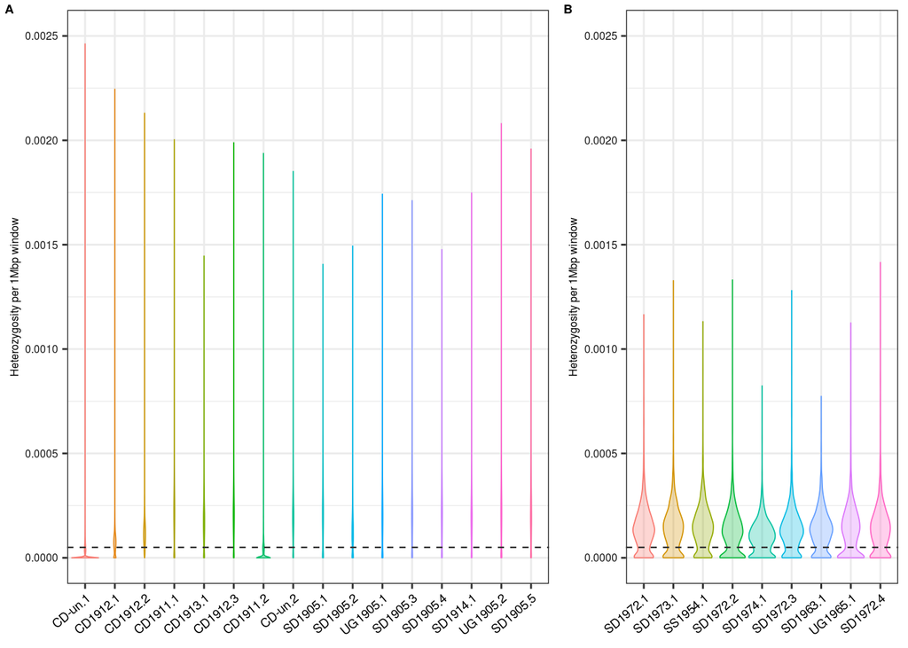

```r
p1 = plot_grid(A, B, nrow=1, ncol=2, labels=c('A','B'), label_size=7, rel_widths = c(1.6,1))
p2 = plot_grid(C, D, nrow=1, ncol=2, labels=c('C','D'), label_size=7, rel_widths = c(1,1.6))
p1
```

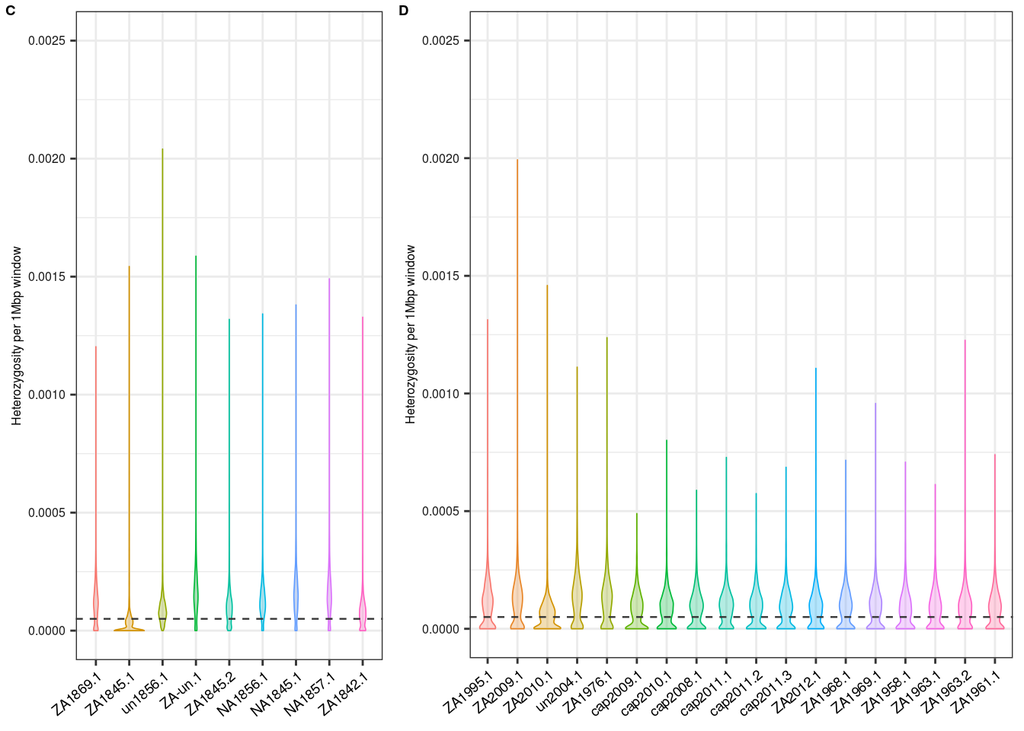

```r
p2
```

Save individual distribution of local het as Figure S7 in WR v3

```r
# pdf('WR_v3_FigS7_v2.pdf', height=5, width=6, useDingbats = F)
# plot_grid(p1, p2, ncol=1, nrow = 2)
# dev.off()
```

Based on these plots we chose 5e-5 as the threshold of low heterozygosity to flag a long-enough region as a RoH. Also we excluded after this we ran the upcoming tests for both the whole sample set and for a set without 3 outliers driven by missing data due to depth of coverage: CD-un.1, CD1911.2, ZA1845.1

## RoH length and Froh in the entire dataset

### 1.a) RoH length in entire dataset

Read in data on RoH number and length for each sample and reshape appropriately

```r
# read in the file to determine the max number of columns
x <- scan("WR_RoH_perscaffold.txt", what = "", sep = "\n")
x <- strsplit(x, "[ \t]+") # split string by white space
max.col <- max(sapply(x, length))

# specify col.names as ?read.table suggests and set old header to missing values
cn <- paste("RoH", 1:max.col, sep = "")
roh <- read.table("WR_RoH_perscaffold.txt", fill = TRUE, col.names = cn, na.strings = "RoH")

# delete old header (first row)
roh = roh[-1,]
```

Calculate length of each RoH per sample

```r
# calculate length of RoH per sample in bp
roh_len = roh*1000000 - ((roh-1)*500000)
```

Add relevant metadata from the ‘data’ dataframe

```r
# bind relevant metadata to the RoHs length
new_ID = data$new_ID
country = data$country
time_window = data$time_window

roh_len_info_raw = cbind(new_ID, country, time_window, roh_len)
```

```r
# melt data with metadata variables as ID
roh_len_info = reshape2::melt(roh_len_info_raw, id.vars = c("new_ID", "country", "time_window"))
```

Prepare a data frame like roh_len_info without the outliers

```r
# filtering 3 outlier samples out
roh_len_info_filt = roh_len_info[roh_len_info$new_ID != 'CD-un.1' & roh_len_info$new_ID != 'CD1911.2' & roh_len_info$new_ID != 'ZA1845.1', ]
```

Filter out isolated windows of low heterozygosity (not considered RoH)

```r
roh_len_info_filt_above1Mb = roh_len_info_filt[roh_len_info_filt$value > 1000000,]
```

This will be the input of the upcoming analyses.

```r
# stats for filtered samples (-3 outliers)
roh_len_info_filt_above1Mb %>%
  filter(!is.na(time_window)) %>%
  group_by(time_window) %>%
  summarize(min=round((min(value)/1000000), digits=4), max=round((max(value)/1000000), digits=4),
            mean=round((mean(value)/1000000), digits=4))
```

```
## # A tibble: 4 x 4
##   time_window   min   max  mean
##   <fct>       <dbl> <dbl> <dbl>
## 1 NWR1          1.5  26.5  2.99
## 2 NWR2          1.5  29    2.96
## 3 SWR1          1.5  21.5  2.61
## 4 SWR2          1.5  41    3.28
```

#### Visualizing the distribution of RoH length per group

Visualize the distribution of RoH length per group for the total dataset (minus outliers)

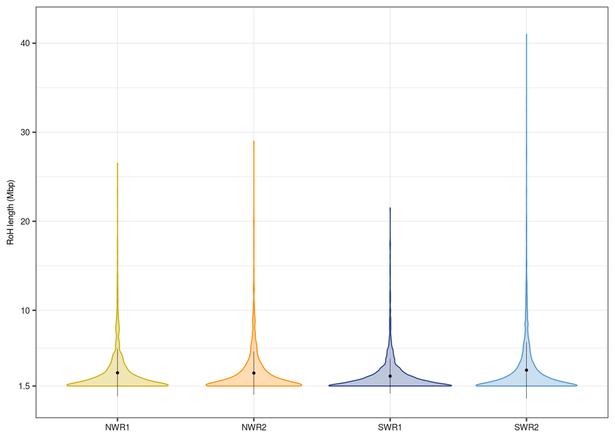

```r
# remove extra NA category mysteriously created by R
roh_len_all = filter(roh_len_info_filt_above1Mb, !is.na(time_window)) %>%

  # plot violins
  ggplot(aes(time_window, value)) +
  theme_bw() + theme(legend.position = "none", axis.text=element_text(size=7, colour='gray10'), axis.title.y=element_text(size=7),
                     panel.grid.major=(element_line(size=.12, colour='gray80'))) +

geom_violin(aes(time_window, value, colour=time_window, fill=time_window), alpha=.3, lwd=.4) +

  # add colours and filling colours
  scale_fill_manual(values= (c("gold3", "darkorange", "royalblue4", "steelblue3"))) +
  scale_color_manual(values= (c("gold3", "darkorange", "royalblue4", "steelblue3"))) +

  # add stats
  stat_summary(fun=mean, size=0.14, fun.min = function (value) mean(value) - sd(value), fun.max = function(value) mean(value) + sd(value), geom = "pointrange", stroke=.5) +

  # embellish
  scale_y_continuous(limits=c(0, 42e6), breaks=c(1.5e6, 10e6, 20e6, 30e6, 40e6), labels=c(1.5, 10, 20, 30, 40)) +

  labs(x=NULL, y="RoH length (Mbp)")

roh_len_all
```

### 1.b) Froh in entire dataset

Calculate FRoH as an estimate of inbreeding by dividing total length falling in RoH by the total genomic length scanned for each sample

```r
# transpose and assign sample IDs as column names
roh_f = t(roh_len)
colnames(roh_f) = data$new_ID

# turn values equal or lower to 1Mbp into missing data
roh_f[roh_f<=1000000]=NA

# sum all remaning values per column and divide by total length of windows screened
# the total length screened is the number of windows multiplied by 1Mbp, minus
# number of windows minus 1 multiplied by 0.5 Mbp ->
# -> (3659 windows*1Mbp) - ((3659-1)*0.5Mbp)

Froh = as.data.frame(colSums(roh_f, na.rm=T) / 1830000000)
colnames(Froh) = "froh"

# add metadata
new_ID = data$new_ID
country = data$country
time_window = data$time_window

# create dataframes for all samples and for filtered set
Froh_f = cbind(new_ID, country, time_window, Froh)
Froh_f_filt = Froh_f[Froh_f$new_ID != 'CD-un.1' & Froh_f$new_ID != 'CD1911.2' & Froh_f$new_ID != 'ZA1845.1', ]
```

```r
Froh_f_filt %>%
  group_by(time_window) %>%
  summarize(min=min(froh, na.rm = TRUE), max=max(froh, na.rm = TRUE), median = median(froh, na.rm = TRUE))
```

```
## # A tibble: 4 x 4
##   time_window   min   max median
##   <fct>       <dbl> <dbl>  <dbl>
## 1 NWR1        0.121 0.339  0.168
## 2 NWR2        0.178 0.267  0.213
## 3 SWR1        0.109 0.356  0.183
## 4 SWR2        0.246 0.467  0.313
```

Statistical comparison of Froh median between pre- and post-bottleneck samples for each subspecies for the filtered data

```r
# data subsetting
nwr1 = Froh_f_filt[Froh_f_filt$time_window == "NWR1",]
nwr2 = Froh_f_filt[Froh_f_filt$time_window == "NWR2",]
swr1 = Froh_f_filt[Froh_f_filt$time_window == "SWR1",]
swr2 = Froh_f_filt[Froh_f_filt$time_window == "SWR2",]

# comparing medians of Froh between pre- and post-bottleneck
wilcox.test(nwr1$froh, nwr2$froh, paired = F)
```

```
##
##  Wilcoxon rank sum test
##
## data:  nwr1$froh and nwr2$froh
## W = 29, p-value = 0.03275
## alternative hypothesis: true location shift is not equal to 0
```

```r
wilcox.test(swr1$froh, swr2$froh, paired = F)
```

```
##
##  Wilcoxon rank sum test
##
## data:  swr1$froh and swr2$froh
## W = 18, p-value = 0.001681
## alternative hypothesis: true location shift is not equal to 0
```

#### Visualizing Froh per group for the entire dataset (minus the 3 outliers, so n=49)

Plot Froh across groups

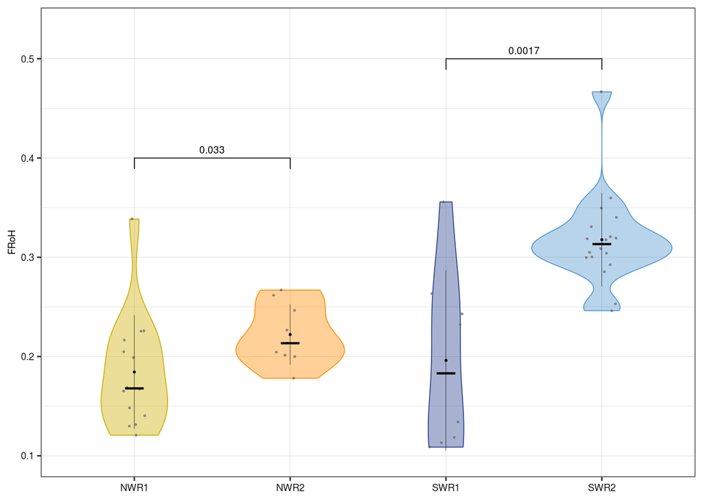

```r
# plot violins per group with stats for filtered sample set but not subsampled
froh_all = ggplot(Froh_f_filt, aes(time_window, froh)) +
  theme_bw() + theme(legend.position = "none", axis.text=element_text(size=7, colour='gray10'), axis.title.y=element_text(size=7),
                     panel.grid.major=(element_line(size=.12, colour='gray80')))


froh_all = froh_all +  geom_violin(aes(colour=time_window, fill=time_window), lwd=.3, alpha=.4) +

  # add scatter points per group
  geom_jitter(colour='gray40', shape=16, position=position_jitter(0.11), cex=.6, alpha=.7) +

  # add colours and filling colours
  scale_fill_manual(values= (c("gold3", "darkorange", "royalblue4", "steelblue3"))) +
  scale_color_manual(values= (c("gold3", "darkorange", "royalblue4", "steelblue3"))) +

  # add stats and an unpaired wilcox test to compare the medians
  stat_summary(fun=median, geom="crossbar", colour='black', width=.12, lwd=.3) +

  stat_summary(fun=mean, fun.min = function (corrected_gw_het) mean(corrected_gw_het) - sd(corrected_gw_het),
               fun.max = function(corrected_gw_het) mean(corrected_gw_het) + sd(corrected_gw_het), geom = "pointrange" , size=.12, stroke=.4, col="black") +

  stat_compare_means(paired=F, method = "wilcox.test", comparisons= list(c("NWR1", "NWR2"), c("SWR1", "SWR2")), label.y=c(0.4, 0.5), size=2.5) +

  # embellish
  scale_y_continuous(limits=c(0.1, 0.53),labels = function(x) format(x, scientific = FALSE)) +

  labs(x=NULL, y="FRoH")

froh_all
```

##### Make RoH len and Froh figure for main text (Figure 4 in WR v3)

```r
# pdf('WR_v3_Fig4_v1.pdf', height=4, width=5, useDingbats = F)
# plot_grid(roh_len_all, froh_all, nrow=1, ncol=2, labels=c('A','B'), label_size=7)
# dev.off()
```

## RoH length and Froh in the subsampled dataset

### 2.a) RoH length in the subsampled dataset

Two out of the three outlier samples removed in RoH analyses, orginate from DRC, so they would be exluded anyway from the calculations below That would leave only one out of three outliers in the subsampled dataset, so we chose to perform these calculations only on the filtered dataset, without any of the 3 outliers

Subsampling by country is therefore an added filtering step on top of removing the 3 outliers (n = 37 final number of samples)

Take already parsed data for RoH length after removing outliers and filter out pertinent samples (from DRC and captive)

```r
roh_len_info_filt_above1Mb_ss = subset(roh_len_info_filt_above1Mb, country != 'DRC' & country != 'captive' | is.na(country))
```

```r
roh_len_info_filt_above1Mb_ss %>%
  filter(!is.na(time_window)) %>%
  group_by(time_window) %>%
  summarize(min=round((min(value)/1000000), digits=4), max=round((max(value)/1000000), digits=4),
            mean=round((mean(value)/1000000), digits=4))
```

```
## # A tibble: 4 x 4
##   time_window   min   max  mean
##   <fct>       <dbl> <dbl> <dbl>
## 1 NWR1          1.5  26.5  3.17
## 2 NWR2          1.5  29    2.96
## 3 SWR1          1.5  21.5  2.61
## 4 SWR2          1.5  41    3.27
```

#### Visualizing the distribution of RoH length per group for the subsampled dataset

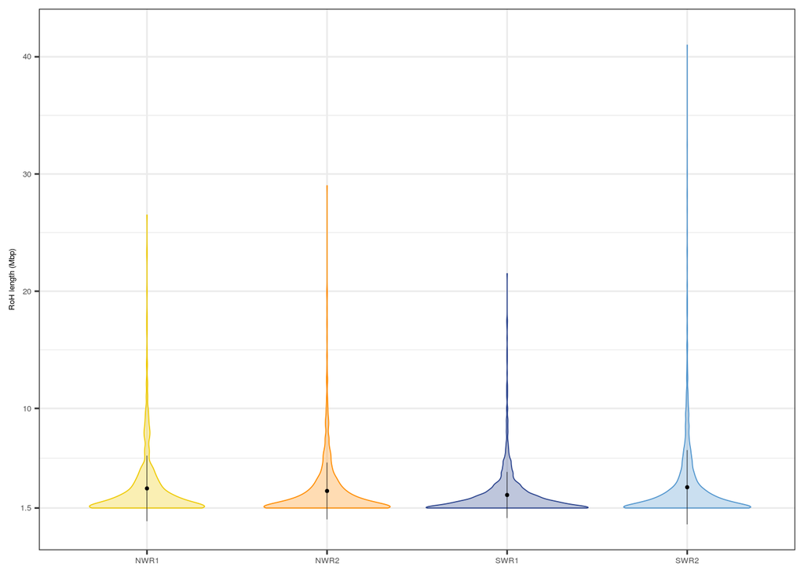

```r
# remove extra NA category mysteriously created by R
roh_len_ss = filter(roh_len_info_filt_above1Mb_ss, !is.na(time_window)) %>%

  # plot violins
  ggplot(aes(time_window, value)) +
  geom_violin(mapping=aes(time_window, value, colour=time_window, fill=time_window), alpha=.3, lwd=.3) +

  # add colours and filling colours
  scale_fill_manual(values= (c("gold2", "darkorange", "royalblue4", "steelblue3"))) +
  scale_color_manual(values= (c("gold2", "darkorange", "royalblue4", "steelblue3"))) +

  # add stats
  stat_summary(fun=mean, size=0.14, fun.min = function (value) mean(value) - sd(value), fun.max = function(value) mean(value) + sd(value), geom = "pointrange", stroke=.5) +

  # embellish
  scale_y_continuous(limits=c(0, 42e6), breaks=c(1.5e6, 10e6, 20e6, 30e6, 40e6), labels=c(1.5, 10, 20, 30, 40)) +
  theme_bw() + theme(legend.position = "none", axis.title=element_text(size=5), axis.text=element_text(size=5)) +
  labs(x=NULL, y="RoH length (Mbp)")

roh_len_ss
```

### 2.b) Froh in the subsampled dataset

Take the relevant values of FRoH, those corresponding to the samples present in the subsampled dataset

```r
Froh_f_filt_ss = subset(Froh_f_filt, country != 'DRC' & country != 'captive' | is.na(country))
```

Get summary statistics for FRoH across groups for the subsampled dataset without outliers (n = 37)

```r
Froh_f_filt_ss %>%
  group_by(time_window) %>%
  summarize(min=min(froh, na.rm = TRUE), max=max(froh, na.rm = TRUE), median = median(froh, na.rm = TRUE))
```

```
## # A tibble: 4 x 4
##   time_window   min   max median
##   <fct>       <dbl> <dbl>  <dbl>
## 1 NWR1        0.131 0.226  0.187
## 2 NWR2        0.178 0.267  0.213
## 3 SWR1        0.109 0.356  0.183
## 4 SWR2        0.246 0.467  0.307
```

Statistical comparison of Froh median between pre- and post-bottleneck samples for each subspecies for the subsampled data (n = 37)

```r
# data subsetting
nwr1 = Froh_f_filt_ss[Froh_f_filt_ss$time_window == "NWR1",]
nwr2 = Froh_f_filt_ss[Froh_f_filt_ss$time_window == "NWR2",]
swr1 = Froh_f_filt_ss[Froh_f_filt_ss$time_window == "SWR1",]
swr2 = Froh_f_filt_ss[Froh_f_filt_ss$time_window == "SWR2",]

# comparing medians of Froh between pre- and post-bottleneck
wilcox.test(nwr1$froh, nwr2$froh, paired = F)
```

```
##
##  Wilcoxon rank sum test
##
## data:  nwr1$froh and nwr2$froh
## W = 19, p-value = 0.1139
## alternative hypothesis: true location shift is not equal to 0
```

```r
wilcox.test(swr1$froh, swr2$froh, paired = F)
```

```
##
##  Wilcoxon rank sum test
##
## data:  swr1$froh and swr2$froh
## W = 13, p-value = 0.005493
## alternative hypothesis: true location shift is not equal to 0
```

#### Visualize Froh across groups for the subsampled dataset

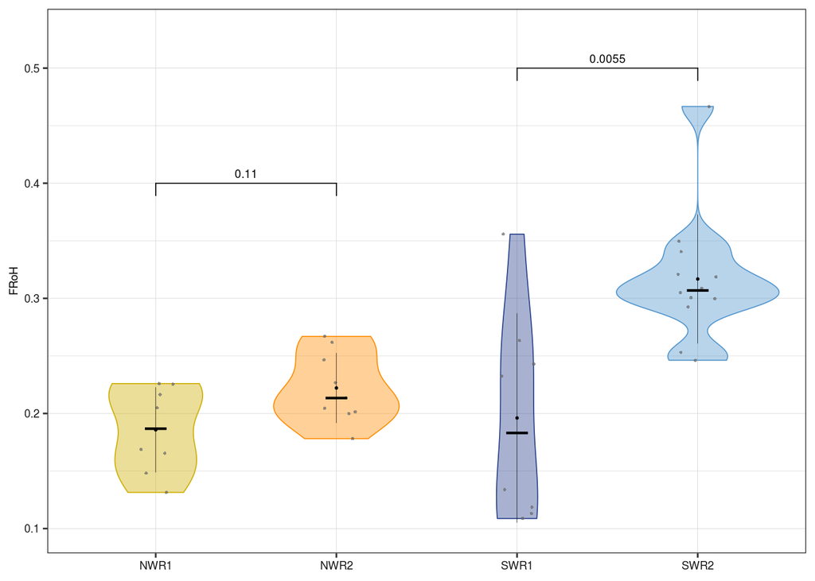

```r
###
# plot violins per group with stats for filtered sample set but not subsampled
froh_ss = ggplot(Froh_f_filt_ss, aes(time_window, froh)) +
  theme_bw() + theme(legend.position = "none", axis.text=element_text(size=7, colour='gray10'), axis.title.y=element_text(size=7),
                     panel.grid.major=(element_line(size=.12, colour='gray80')))


froh_ss = froh_ss +  geom_violin(aes(colour=time_window, fill=time_window), lwd=.3, alpha=.4) +

  # add scatter points per group
  geom_jitter(colour='gray40', shape=16, position=position_jitter(0.11), cex=.6, alpha=.7) +

  # add colours and filling colours
  scale_fill_manual(values= (c("gold3", "darkorange", "royalblue4", "steelblue3"))) +
  scale_color_manual(values= (c("gold3", "darkorange", "royalblue4", "steelblue3"))) +

  # add stats and an unpaired wilcox test to compare the medians
  stat_summary(fun=median, geom="crossbar", colour='black', width=.12, lwd=.3) +

  stat_summary(fun=mean, fun.min = function (corrected_gw_het) mean(corrected_gw_het) - sd(corrected_gw_het),
               fun.max = function(corrected_gw_het) mean(corrected_gw_het) + sd(corrected_gw_het), geom = "pointrange" , size=.12, stroke=.4, col="black") +

  stat_compare_means(paired=F, method = "wilcox.test", comparisons= list(c("NWR1", "NWR2"), c("SWR1", "SWR2")), label.y=c(0.4, 0.5), size=2.5) +

  # embellish
  scale_y_continuous(limits=c(0.1, 0.53),labels = function(x) format(x, scientific = FALSE)) +

  labs(x=NULL, y="FRoH")

froh_ss
```

##### Make RoH len and Froh figure for supplementary

```r
# pdf('WR_v3_FigS9_v1.pdf', height=4, width=5, useDingbats = F)
# plot_grid(roh_len_ss, froh_ss, nrow=1, ncol=2, labels=c('A','B'), label_size=7)
# dev.off()
```